# Линкор Montañés против французской эскадры

2021-03-20

Статья [Todo a babor](https://www.todoababor.es/historia/navio-montanes-contra-escuadra-francesa), автор Juan García

# Битва корабля Montañés

В марте 1795 года 74-пушечный линкор Montañés входил в состав Океанической эскадры Королевской Армады генерал-лейтенанта Хуана де Лангары, в то время находящейся в Средиземном море. Montañés совсем недавно был спущен на воду, и его экипаж стремился приступить к своим первым операциям. Им командовал капитан корабля (capitán de navío) Хосе Хордан-и-Мальтес, который 17 марта принял участие в захвате французского 32-пушечного фрегата Ifigenia (26 12-фунтовых орудий и 6 6-фунтовых). Однако это событие является темой другой статьи, мы упоминаем о нем потому, что часть французских пленных оказалась на борту Montañes и стала свидетелем его следующей битвы.

## Обнаружение французской эскадры

[figure not shown]

El Montañés, автор Rafael Castex

30 марта в одиночку курсирующий Montañés находился в 5 лигах (15 морских миль) на юго-восток от мыса Сан-Себастьян, около Жироны, с дующим на север ветром. На его борту находились 300 цыплят, 100 баранов и 30 коров для снабжения эскадры, погруженные в порту Маон, а также французские пленные с захваченного фрегата. Вдруг на большом расстоянии с подветренной стороны появились 10 крупных военных кораблей. Испанцы думали, что это может быть британская эскадра, поэтому капитан взял курс на нее. Напомним, что в то время две страны были союзниками, хотя в это не всегда можно было поверить. Испанский командир хотел знать, чем закончился бой британцев с французской Эскадрой Тулона у побережья Италии. Он считал, что такие важные новости необходимо сообщить его начальнику Лангаре. Упомянутое сражение - так называемая битва при Генуе (или мыса Ноли) - состоялось 14 марта 1795 года в Генуэзском заливе и закончилось победой британцев с небольшой помощью неаполитанских союзников.

Montañés использовал опознавательные сигналы, чтобы получить ответ от эскадры. Но на столь большом расстоянии испанцы не могли разглядеть его. Кажется, что капитан был очень наивен, решив приблизиться к неопознанной эскадре, однако он сохранил расстояние в одну лигу и всегда придерживался наветренной стороны. Кроме того, по словам самого Хордана, отчитывающегося за выдающиеся действия Montañés, он оставлял за собой возможность без какого-либо риска сбежать, в случае обнаружения врага, что в результате и произошло с ним.

Капитан повторно поднял опознавательные сигналы, но эскадра их проигнорировала. При приближении испанцы увидели свои флаги, которые вскоре были предательски спущены. И на мачты кораблей взлетели настоящие французские триколоры. Хордан заявлял, что эта вражеская эскадра состояла из 10 кораблей - 8 линкоров и 2 фрегатов, однако эти слова требуют проверки, поскольку испанский капитан упомянул в своем отчете один трехпалубный линкор, но французские источники не подтверждают его участие. Французский историк Чарльз Рувье в своей работе Histoire des Marins Français Sous La République 1789-1803 говорит, что в эскадру входили 6 линкоров и 4 фрегата - в сумме так же 10 судов.

Французская эскадра на всех парусах начала охоту на Montañés. Она продолжалась с 11 утра 30 марта до 9 утра следующего дня, когда испанский корабль спрятался в небольшой бухте городка Сан-Фелиу-де-Гишольс в окрестностях Жироны. Там он встал на якорь, выиграв время, чтобы подготовиться к настоящему сражению, если французы решат возобновить свою погоню. Мы вновь должны подчеркнуть великолепные действия Montañés, поскольку, кроме крупных линкоров, в погоне принимали участие более легкие и маневренные фрегаты, но ни один из них не смог приблизиться к испанцу. Что, как было сказано выше, предоставило капитану самый необходимый ресурс, а именно, время.

## Бухта Сан-Фелиу-де-Гишольс

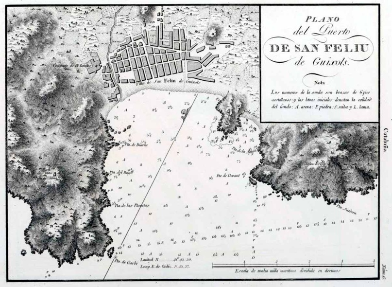

План бухты Сан-Фелиу

Следует напомнить, что размеры линкоров не позволяли им маневрировать около побережья, тем более в водах, глубина которых практически неизвестна французам. В таких условиях ни один командир не рискнет своим кораблем, чтобы получить преимущество над противником, готовым защищаться в местных водах. Попытки сломить сопротивление Montañés, атаковать его сильным огнем с борта сопровождались высоким шансом сесть на мель или разбить корабль у побережья.

Капитан Хосе Хордан был прав, выбрав эту бухту. Она позволяла ему сопротивляться, невзирая на значительно превосходящую мощь французских кораблей. К сожалению, на месте не оказалось трех канонерок, призванных защищать воды Сан-Фелиу - командующий станцией Жироны отправил их в Паламос, оставив Montañés без столь ценной поддержки. Однако в полном порядке была береговая батарея, которая вела огонь по французам и помогала выгонять из входа в бухту.

Несмотря на незначительное участие батареи, можно сказать, что Montañés сражался с французами в одиночку. Вражеская эскадра приготовилась атаковать испанца. 7 кораблей последовательно с большого расстояния открывали массированный огонь, угрожая Montañés. Испанский капитан не поддавался страху и постоянно отвечал своим противникам, сделал более 1100 залпов за эти 2,5 часа боя.

## После сражения

Наконец, французы прекратили огонь и вышли из боя. Они ушли вдоль побережья к мысу Креус, потратив впустую несколько часов на неуступчивого испанца. Удивительно, но Montañés, выстоявший в бою против 7 французских кораблей, практически не получил повреждений. После непродолжительного ремонта корабль дождался благоприятных ветров и отправился на Менорку, куда он прибыл 14 мая, больше не обнаружив на своем пути никаких препятствий.

[figure not shown]

Сражение Montañés, автор Carlos Parrilla Penagos

Через 28 часов после окончания боя о произошедшем узнал генерал-лейтенант Лангара и вместе с 16 линкорами и 8 фрегатами отправился к Маону в поисках французской эскадры, но так ее и не нашел. Капитан Хосе Хордан сообщил о наличии 20 пробоин в борту и об опасности разрушения марса-рея и части такелажа. Удивительно малый ущерб при столкновении с настолько превосходящими силами противника.

Обратим особое внимание на артиллерийское вооружение, поскольку Montañés нес 24-фунтовые пушки на своей нижней батарее, а французы - 36-фунтовые.

Потери экипажа также были курьезными. Капитану пришлось сожалеть всего лишь о гибели комендора (артиллериста) и двух моряков. Кроме того, среди них и солдат морской пехоты было не более 20 раненых.

Испанский капитан ничего не мог знать о французских повреждениях и потерях, но он выразил следующее предположение в своем отчете:

> Думаю, что враги получили порядочный ущерб по своим бортам и парусам. Я заметил, что у одного из них расколот фор-марса-рей, а у другого - мартин-гик.

В Gaceta de Madrid было также сказано:

> Из отчета старшины на фелуге, который попал в плен, а затем был отпущен на свободу, стало известно, что залп испанского корабля насквозь прошил два борта французского судна, на котором он находился. Экипаж этого французского корабля насчитывал 800 человек, из которых 200 выбыли по болезни. На другом корабле было 400 человек. Старшина слышал, что эта эскадра 32 дня назад вышла из Бреста, чтобы присоединиться к остальным в Тулоне.

Таковы первоначальные данные о низкой эффективности французских артиллеристов. Кроме того, на их кораблях было очень много больных, что повлияло на ход сражения. Почему тогда они рискнули вступить в бой? Конечно, они сочли, что захват одиночного корабля не потребует от них значительных усилий, и что приятно было бы прийти из длительного путешествия в Тулон со столь крупным призом. Увидев, что испанец был твердым орешком, французы решили больше не рисковать своими ценными кораблями в этой стычке.

## Французская эскадра

[figure not shown]

Портрет Жана Франсуа Ренодена

> Я охотился за испанским линкором; но штиль и пришедшие на помощь суда лишили Республику этого корабля.

О каких кораблях говорил французский офицер? Как мы уже упоминали, канонерки, обычно стоящие на якоре в Сан-Фелиу, находились в Паламосе. Кого увидел Реноден - непонятно, впрочем, это стандартное явление, когда мы рассматривает ситуации такого рода.

[figure not shown]

Модель Achille, созданного по одному проекту с Jemmapes

В октябре 1794 года в Бресте Реноден поднял свой флаг на Jemmapes, 74-пушечном линкоре, и в марте 1795 тот оставался флагманом его эскадры. Согласно Service Historique de la Défense Marine Vincennes, также в ее состав входили:

- Jemmapes, 74 cañones
- Montagnard, 74 cañones
- Tyrannicide, 74 cañones
- Trente-et-un Mai, 74 cañones
- Aquilon, 74 cañones
- Révolution, 74 cañones
- Courageuse, 32 cañones
- Embuscade, 32 cañones
- Félicité, 32 cañones
- Unité, 32 cañones

Так закончилось это малоизвестное сражение, демонстрирующее стойкость и мужество командира Montañés и его экипажа.